# Bioestadistica con R

# 6 *KRUSKAL WALLIS*

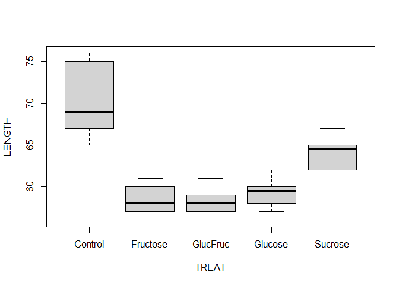

```r
#Prueba de Kruskal-Wallis con prueba post-hoc no parametrica
##Ejem: Sokal y Rohlf (1997) presentan un conjunto de datos no publicados
#(W. Purves) en el que el efecto de Tratamientos de az?car en diferentes %
#(Control, 2% de glucosa agregada, 2% de fructosa agregada, 1% de glucosa
#y Se investig? el 1% de fructosa y el 2% de sacarosa en la longitud
#de guisante.


#usamos los datos Purvey
purves <- read.table("purves.csv", header = T, sep = ",")

#vemos las tendencias de normalidad
par(mfrow=c(1, 1))
boxplot(LENGTH ~ TREAT, data = purves)
```

```r
ggbetweenstats(
  data = purves,
  x = TREAT,
  y = LENGTH,
  pairwise.display = "no significant"
)
```

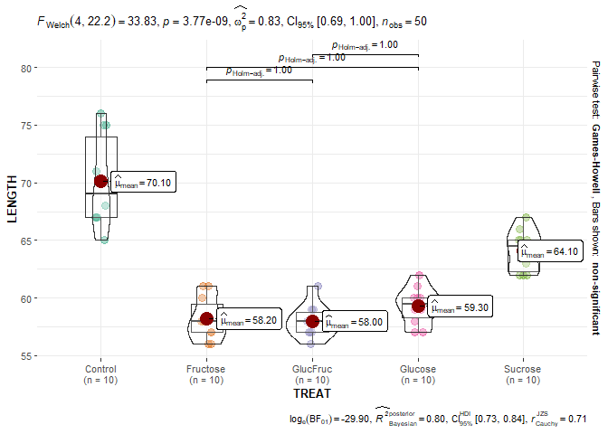

```r
#hay fuertes diferencias de varianzas, tendencia no param?trica

#hacemos el analisis kruskall
kruskal.test(LENGTH~TREAT, data = purves)
```

```
##
##  Kruskal-Wallis rank sum test
##
## data:  LENGTH by TREAT
## Kruskal-Wallis chi-squared = 38.437, df = 4, p-value = 9.105e-08
```

```r
#nos dice que si hay diferecnia significativa, la cantidad de azucar
#influencia

#Un estudio compara el numero de huevos que pone la mosca infecciosa Culex
#bajo 3 ambientes distintos. ?Existen diferencias significativas
#dependiendo de las condiciones?

insecto = data.frame(condicion = c(rep("bosque", 18), rep("potrero", 18),
                                   rep("ciudad", 18)), n_huevos = c(1, 2, 3, 4, 5, 6, 7, 8, 9,
                                                                    16, 27, 28, 29, 30, 51, 52, 53, 342, 40, 41, 42, 43, 44, 45, 46,
                                                                    47, 48, 67, 88, 89, 90, 91,92, 93, 94, 293, 19, 20, 21, 22, 23,
                                                                    24, 25, 26, 27, 28, 25, 36, 37, 58, 59, 60, 71, 72))
head(insecto)
```

|  | condicion | n_huevos |
| --- | --- | --- |
| 1 | bosque | 1 |
| 2 | bosque | 2 |
| 3 | bosque | 3 |
| 4 | bosque | 4 |
| 5 | bosque | 5 |
| 6 | bosque | 6 |

```r
aggregate(n_huevos ~ condicion, data = insecto, FUN = median)
```

| condicion | n_huevos |
| --- | --- |
| bosque | 12.5 |
| ciudad | 26.5 |
| potrero | 57.5 |

```r
aggregate(n_huevos ~ condicion, data = insecto, FUN = sd)
```

| condicion | n_huevos |
| --- | --- |
| bosque | 78.10637 |
| ciudad | 18.59097 |
| potrero | 58.41750 |

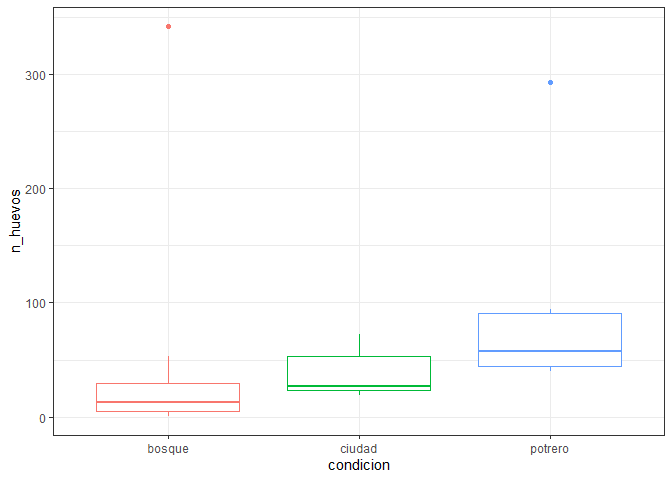

```r
library(ggplot2) #habilitammos el ggplot2

#aplicamos boxplot para ver la dispersion de los datos
ggplot(data = insecto, mapping = aes(x = condicion, y = n_huevos,
                                     col = condicion)) +   geom_boxplot() +
  theme_bw() + theme(legend.position = "none")
```

```r
ggbetweenstats(
  data = insecto,
  x = condicion,
  y = n_huevos,
  pairwise.display = "no significant"
)
```

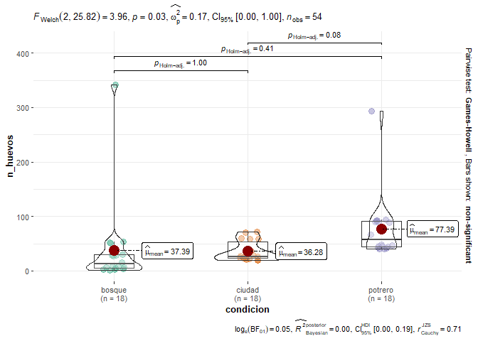

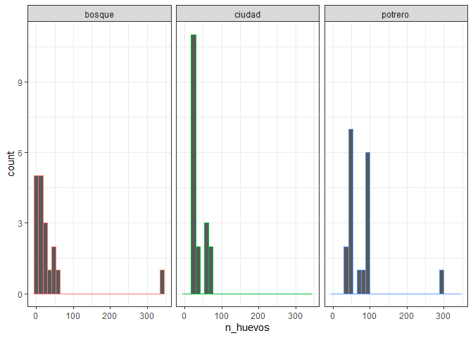

```r
#aplicamos un histograma
ggplot(data = insecto, mapping = aes(x = n_huevos, colour = condicion)) +
  geom_histogram() + theme_bw() + facet_grid(. ~ condicion) +
  theme(legend.position = "none")
```

```r
#La representacion grafica de los datos muestra que las muestras no se
#distribuyen de forma normal, lo que supone una limitacion para emplear
#un test ANOVA. Las tres muestras presentan el mismo tipo de distribucion,
#asimetria hacia la derecha, a falta de comprobar la homogeneidad de varianza
#el test de Kruskal-Wallis es la opcion m?s adecuada.


#Condiciones

#Homocedasticidad: la varianza debe de ser constante entre todos los grupos.

library(car)
leveneTest(n_huevos ~ condicion, data = insecto, center = "median")
```

|  | Df | F value | Pr(>F) |
| --- | --- | --- | --- |
| group | 2 | 0.7929454 | 0.458009 |
|  | 51 | NA | NA |

```r
#No se muestra evidencias en contra de la homogeneidad de varianzas.

#Aplicamos la pruerba de Kruskall wallis

kruskal.test(n_huevos ~ condicion, data = insecto)
```

```
##
##  Kruskal-Wallis rank sum test
##
## data:  n_huevos by condicion
## Kruskal-Wallis chi-squared = 19.964, df = 2, p-value = 4.623e-05
```

```r
#El test encuentra significancia en la diferencia de al menos dos grupos.

#Comparaciones post-hoc para saber que dos grupos difieren
#Existen diferentes m?todos de correcci?n del nivel de significancia,
#entre ellos destacan el de Bonferroni que es muy estricto y el de holm,
#este ultimo parece ser m?s recomendado.

pairwise.wilcox.test(x = insecto$n_huevos, g = insecto$condicion,
                     p.adjust.method = "holm" )
```

```
##
##  Pairwise comparisons using Wilcoxon rank sum test with continuity correction
##
## data:  insecto$n_huevos and insecto$condicion
##
##         bosque  ciudad
## ciudad  0.04795 -
## potrero 0.00029 0.00058
##
## P value adjustment method: holm
```

```r
#Solucion
#Entre los tres ambientes hay diferencias significativas en cuanto a la
#produccion de huevos de las moscas Culex
```

# 7 *Metodos de ordenación*

## 7.1 Analsis de componentes principales PCA

El análisis de componentes principales (PCA) es una técnica multivariada utilizada para explorar y reducir la dimensionalidad de conjuntos de datos grandes y complejos. Su objetivo principal es encontrar patrones o estructuras subyacentes en los datos, lo que permite resumir la información contenida en múltiples variables en un conjunto más pequeño de variables llamadas componentes principales.

Por ejemplo, consideremos un estudio que recolecta datos sobre diferentes ambientes forestales, como la densidad de árboles, la temperatura, la precipitación y la presencia de mamíferos. Estos datos pueden ser representados como puntos en un espacio multidimensional, donde cada dimensión corresponde a una variable medida. El PCA busca identificar combinaciones lineales de estas variables que capturen la mayor cantidad de variabilidad en los datos.

Interpretar los resultados del PCA implica comprender cómo las variables originales contribuyen a cada componente principal identificado. Por ejemplo, si un componente principal captura una gran cantidad de variabilidad en la densidad de árboles y la temperatura, podemos inferir que estas dos variables están fuertemente relacionadas en los datos.

Además, la posición de los puntos en el espacio de componentes principales puede proporcionar información sobre la similitud entre las observaciones. Por ejemplo, si dos puntos están cerca en el espacio de componentes principales, esto sugiere que las observaciones correspondientes son similares en términos de las variables medidas.

En resumen, el PCA es una herramienta poderosa para explorar la estructura de los datos multivariados y puede ayudar a identificar patrones, reducir la dimensionalidad de los datos y entender las relaciones entre las variables.

Analsis multivariados, son datos grandes aleatorios, a traves de estos metodos poder encontrar un orden o agrupacion. Ejemplo: diferentes ambientes, bosque alto donde hay factores ambientales favorables y otro que seria los animales, otro ambiente donde el bosque es menor y hay mas lluvias por lo cual hay facotres ambientales diferentes y otra variable son los maniferos, y lo que buscamos con la tecnica es relacionar si las varaibles incluyen en la abundancia de mamiferos. Si los datos se agrupan en el centro significa que no estan influenciada

```r
# instalamos esos paquetes

library(ggpubr)
library(factoextra)
```

```r
####################       ANALISIS PCA        ####################

## • Compute PCA using the R base function prcomp()
## • Visualize the output using the factoextra R package (an extension to ggplot2)
## (Kassambara and Mundt, 2017)

nodupca = read.table("nodupca.txt", header = TRUE)

str(nodupca)
```

```
## 'data.frame':    22 obs. of  12 variables:
##  $ pH2   : num  1 1 1 1 0.5 1 1 1 1 1 ...
##  $ Tem13 : int  2 2 2 2 2 2 2 2 2 2 ...
##  $ Tem42 : num  1 0.667 3 1 2 ...
##  $ Sal8  : num  0.2 0 1 2 0.5 0 0 0 1.5 2 ...
##  $ Sal6  : num  1.2 0 1.5 3 2 1 1 1 2.75 3 ...
##  $ Sal4  : num  2 1.33 3 2 2.5 ...
##  $ pH9   : num  1.8 3.33 1.5 1 1.5 ...
##  $ Tem4  : num  1.2 1.33 2 2 1.5 ...
##  $ pH4   : num  1.6 3.33 1.5 2 1 ...
##  $ Sal1.5: num  2.2 2.33 3 3 2.5 ...
##  $ Sal2.5: num  2.2 1.33 3.5 3 2.5 ...
##  $ pH8   : num  2.2 3.67 2.5 2 2.5 ...
```

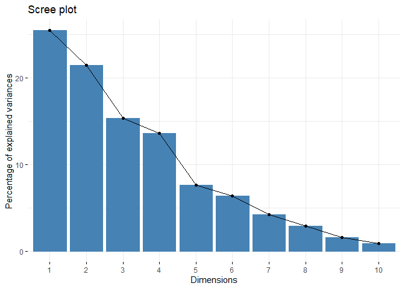

```r
library("factoextra")
nodPCA = nodupca # Remove the grouping variable
res.pca = prcomp(nodPCA, scale = TRUE)
fviz_eig(res.pca) ## Para halar el aporte de las varianzas
```

Este gráfico representa las dimensiones y su contribución, donde la primera dimensión aporta un 26% del total. Sin embargo, debido a la gran cantidad de dimensiones, la explicación se vuelve difícil y poco clara. Para abordar esta complejidad, es necesario filtrar las variables más influyentes que puedan explicar las relaciones entre las dimensiones. Esto se debe a que el gran número de variables puede dificultar la comprensión de los patrones subyacentes y hacer que la interpretación sea menos precisa. Al identificar y centrarse en las variables más relevantes, se puede mejorar la comprensión y la interpretación de los datos, permitiendo una visión más clara y significativa de las relaciones presentes en el conjunto de datos.

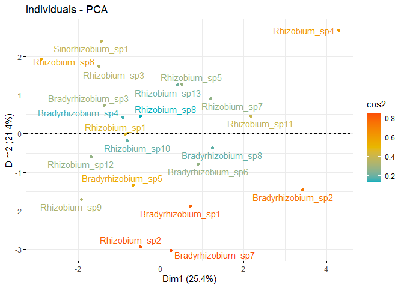

```r
fviz_pca_ind(res.pca,
             col.ind = "cos2", # Color by the quality of representation
             gradient.cols = c("#00AFBB", "#E7B800", "#FC4E07"),
             repel = TRUE )    # Avoid text overlapping
```

Este análisis indica la presencia de puntos extremos en la distribución de bacterias, lo que sugiere una notable capacidad de adaptación a diferentes niveles de salinidad. Estos puntos extremos podrían indicar cepas de bacterias que pueden sobrevivir y prosperar en condiciones de salinidad muy alta o muy baja. Esta adaptabilidad es un rasgo destacado que puede ser crucial en entornos cambiantes o variables, donde la concentración de salinidad puede fluctuar significativamente. La presencia de estas bacterias extremas puede tener implicaciones importantes en diversos campos, como la biotecnología y la ecología, donde comprender y aprovechar la capacidad de adaptación de organismos puede conducir a aplicaciones innovadoras o a una mejor comprensión de los ecosistemas.

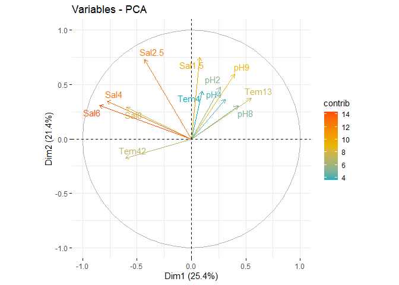

```r
fviz_pca_var(res.pca,
             col.var = "contrib", # Color by contributions to the PC
             gradient.cols = c("#00AFBB", "#E7B800", "#FC4E07"),
             repel = TRUE  )   # Avoid text overlapping
```

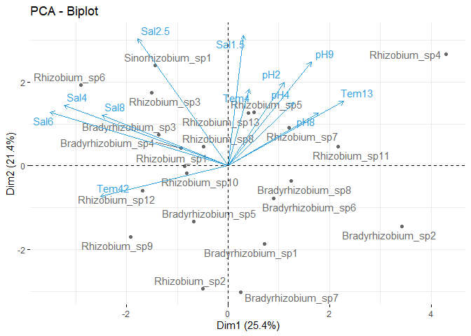

```r
##variables y dimensiones

fviz_pca_biplot(res.pca, repel = TRUE,
                col.var = "#2E9FDF", # Variables color
                col.ind = "#696969")  # Individuals color
```

```r
### Para la variable Temperaturas

nodutemp = read.table("noduTemp.txt", header = TRUE)

nodutemp
```

|  | Tem4 | Tem13 | Tem40 |
| --- | --- | --- | --- |
| Bradyrhizobium_sp1 | 1.200000 | 2 | 1.0000000 |
| Bradyrhizobium_sp2 | 1.333333 | 2 | 0.6666667 |
| Bradyrhizobium_sp3 | 2.000000 | 2 | 3.0000000 |
| Bradyrhizobium_sp4 | 2.000000 | 2 | 1.0000000 |
| Bradyrhizobium_sp5 | 1.500000 | 2 | 2.0000000 |
| Bradyrhizobium_sp6 | 2.000000 | 2 | 2.0000000 |
| Bradyrhizobium_sp7 | 1.000000 | 2 | 2.0000000 |
| Bradyrhizobium_sp8 | 1.000000 | 2 | 1.5000000 |
| Rhizobium_sp1 | 1.500000 | 2 | 2.5000000 |
| Rhizobium_sp10 | 1.500000 | 2 | 3.0000000 |

[output cut: 12 more lines]

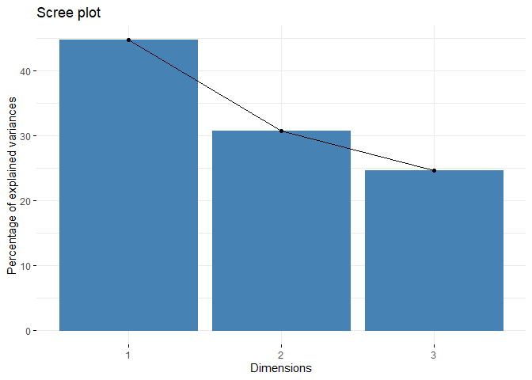

```r
library("factoextra")
res.pca = prcomp(nodutemp, scale = TRUE)
fviz_eig(res.pca) ## Para halar el aporte de las varianzas
```

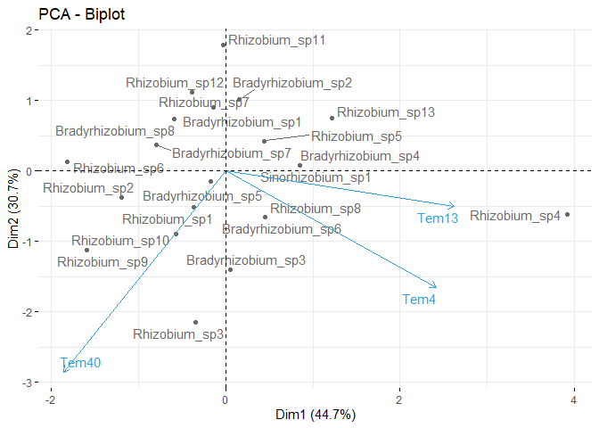

```r
fviz_pca_biplot(res.pca, repel = TRUE,
                col.var = "#2E9FDF", # Variables color
                col.ind = "#696969")  # Individuals color
```

Esta observación resalta que la dimensión uno explica el 44.7% de la variabilidad, seguida por el 30% en la dimensión dos. Además, se destaca que en el centroide no se evidencia un grado de relación o explicación respecto a las variables de temperatura. Se menciona específicamente que el Rhizobium_sp4 logró sobrevivir o soportar la temperatura de 13 grados Celsius. También se señala que las bacterias ubicadas en la parte superior del gráfico no están agrupadas con las otras variables.

Esta descripción sugiere que la dimensión uno tiene un impacto significativo en la variabilidad de los datos, seguida por la dimensión dos. Además, destaca una falta de relación aparente entre el centroide y las variables de temperatura, lo que sugiere que estas últimas podrían no estar directamente asociadas con los patrones observados en el conjunto de datos. La supervivencia o resistencia del Rhizobium_sp4 a una temperatura específica indica una capacidad de adaptación a condiciones ambientales adversas. Por último, la falta de agrupación de las bacterias en la parte superior del gráfico con otras variables puede indicar una diferencia notable en su comportamiento o respuesta a los tratamientos en comparación con las demás bacterias.

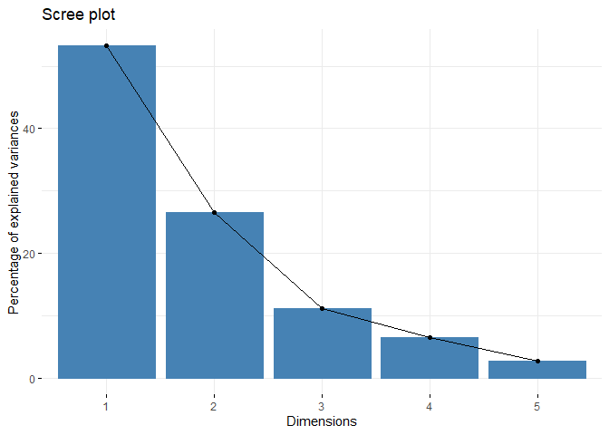

```r
### Para Salinidad
nodusal = read.table("noduSal.txt", header = TRUE)
res.pca <- prcomp(nodusal, scale = TRUE)
fviz_eig(res.pca) ## Para halar el aporte de las varianzas
```

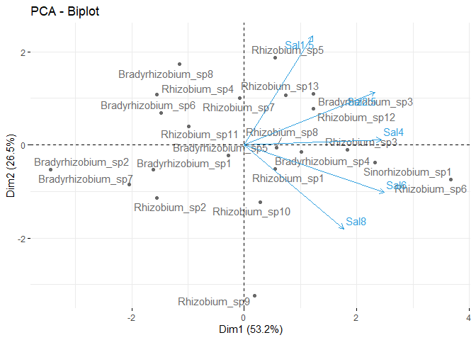

```r
fviz_pca_biplot(res.pca, repel = TRUE,
                col.var = "#2E9FDF", # Variables color
                col.ind = "#696969")  # Individuals color
```

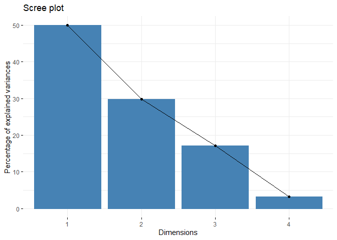

```r
### Para pH
noduph = read.table("nodupH.txt", header = TRUE)
res.pca <- prcomp(noduph, scale = TRUE)
fviz_eig(res.pca) ## Para halar el aporte de las varianzas
```

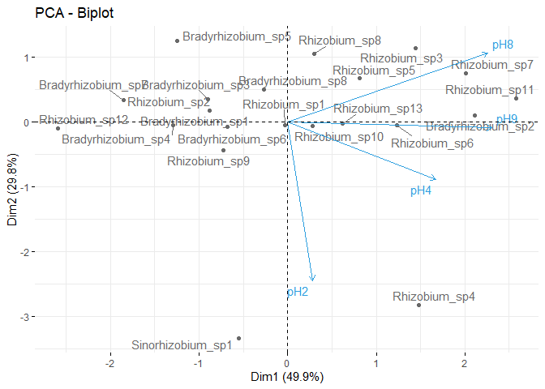

```r
fviz_pca_biplot(res.pca, repel = TRUE,
                col.var = "#2E9FDF", # Variables color
                col.ind = "#696969")  # Individuals color
```